# Exploratory Data Analysis in R - Protection for Persons in Care

# List of Tables and Figures

### List of Figures

# Introduction

The purpose of this assignment is to carry out Exploratory Data Analysis (EDA), to better understand EDA techniques in R and the creation of pdf reports via RMarkdown.

The following report will:

- Describe the data using summary statistics
- Examine and visualize the distribution of variables via bar charts, histograms, and line plots
- Examine and visualize covariation via box plots, heatmaps, and scatterplots
- Describe, discuss, and summarize the results

The dataset utilized for this project was obtained from the Government of Nova Scotia’s Open Data Portal. The dataset, *Referrals, Investigations and Founded Cases - Licensing Services & Protection for Persons in Care*, was compiled by the Department of Community Services and last updated on November 5, 2021. The dataset outlines cases of alleged abuse against residents in licensed Department of Community Services facilities, as well as the year and fiscal quarter during which it took place.

Within the dataset, there are three categories of abuse cases; the first are referrals, which are reported allegations of abuse against a resident. The second are investigations, which occur after an inquiry process into a referral has taken place, and it is determined that abuse, or future abuse, is probable. Lastly, founded cases are cases in which the investigation revealed that it is likely that abuse has occurred.

According to the Government of Nova Scotia (2021), the dataset is updated consistently to uphold two Acts for the protection of vulnerable Nova Scotians:

“The Protection for Persons in Care Act is an extra safeguard for patients or residents 16 years of age or older receiving care from Nova Scotia’s hospitals, residential care facilities, nursing homes, homes for the aged or disabled persons under the Homes for Special Care Act” (para. 2).

Through EDA, it is expected that the larger facilities, with more staff and more residents, will have higher referrals, investigations, and founded cases when compared to smaller facilities. It is also probable that the COVID-19 pandemic has altered the referral rate for the 2020 and 2021 time frames when compared to previous years. Indeed, it is possible that referral rates went up due to staffing shortages and the resultant neglect, or down due to facility visitation restrictions. As well, it is plausible that the time of year (identified through the fiscal quarter), may impact referrals. For instance, heat or the winter holidays may result in staff shortages, contributing to abuse and neglect (Bonnie & Wallace, 2003, p. 484).

# Data Selection and Preparation

The dataset was gathered from the Nova Scotia Open Data Portal. This dataset, and those that are similar and can be accessed by the public, are of utmost importance for the creation of legislation that ensures quality of care. This is especially true considering the recent media coverage of abuse and neglect of persons in care during the COVID-19 pandemic, and the public outcry for increased protection for persons in care that has followed. Additionally, as a former health care assistant, I felt I had knowledge that could contribute to the analysis of the dataset.

The dataset was exported and downloaded from the Government of Nova Scotia’s Open Data Portal in CSV format, and ‘read’ into RStudio as a CSV file. The data tidying process required the transformation of three character values into factors, including facility type, fiscal year, and quarter. It also involved changing the names of some variables for clarity; for instance, ‘facility.type’ was changed to ‘facility_type’. The data frame was also converted to a tibble to ensure that the data format remained intact, and to ensure exact subsetting of the data, both of which are more difficult when using a data frame. R code was also used to determine if null values are contained within the dataset, and while 0 values exist in the data (such as for 0 founded cases), no null values exist.

# Data Summary

The first six rows of the categorical variables

| Facility_type | Fiscal_year | Quarter |
| --- | --- | --- |
| Adult Residential Centre (ARC) | 2017-18 | Q1 Apr-June |
| Developmental Residence | 2017-18 | Q1 Apr-June |
| Group Home | 2017-18 | Q1 Apr-June |
| Residential Care Facility (RCF) | 2017-18 | Q1 Apr-June |
| Residential Rehabilitation Centre (RRC) | 2017-18 | Q1 Apr-June |
| Small Options Home | 2017-18 | Q1 Apr-June |

Table 1 displays all the categorical variables contained within the dataset, which include facility type, fiscal year, and fiscal quarter (identified only as ‘quarter’), along with the first six rows of the dataset.

The first six rows of the integer (numeric) variables

| Referrals | Investigations | Founded_cases |
| --- | --- | --- |
| 6 | 2 | 0 |
| 2 | 1 | 1 |
| 8 | 3 | 0 |
| 2 | 1 | 1 |
| 1 | 0 | 3 |
| 8 | 0 | 1 |

Table 2 displays the numeric variables (held as integers) contained within the dataset, which include referrals, investigations, and founded cases, along with the first six rows of the dataset.

Summary statistics for the categorical variables

|  | Facility_type | Fiscal_year | Quarter |
| --- | --- | --- | --- |
|  | Adult Residential Centre (ARC) :18 | 2017-18:24 | Q1 Apr-June:32 |
|  | Developmental Residence :18 | 2018-19:24 | Q2 Jul-Sep :32 |
|  | Group Home :18 | 2019-20:26 | Q3 Oct-Dec :26 |
|  | Other : 8 | 2020-21:28 | Q4 Jan-Mar :26 |
|  | Residential Care Facility (RCF) :18 | 2021-22:14 | NA |
|  | Residential Rehabilitation Centre (RRC):18 | NA | NA |
|  | Small Options Home :18 | NA | NA |

Table 3 contains summary statistics for the categorical variables within the dataset, and details the count of each variable (to the right of the variable) including facility type, fiscal year, and quarter.

Summary statistics for the integer variables

|  | Referrals | Investigations | Founded_cases |
| --- | --- | --- | --- |
|  | Min. : 0.000 | Min. :0.000 | Min. :0.0000 |
|  | 1st Qu.: 3.000 | 1st Qu.:0.000 | 1st Qu.:0.0000 |
|  | Median : 5.000 | Median :1.000 | Median :1.0000 |
|  | Mean : 5.509 | Mean :1.638 | Mean :0.9741 |
|  | 3rd Qu.: 8.000 | 3rd Qu.:2.000 | 3rd Qu.:2.0000 |
|  | Max. :17.000 | Max. :9.000 | Max. :8.0000 |

Table 4 contains summary statistics for the numeric variables within the dataset, including the minimum, maximum, and mean. For example, the mean number of referrals per facility type is identified as 5.5, while the maximum number of referrals for a particular facility is 17. Similarly, the mean number of investigations is 1.6, while maximum number of investigations is 9. Finally, the mean for founded cases is .97, while the maximum number of founded cases for a specific facility is 8.

# Exploration of Variation

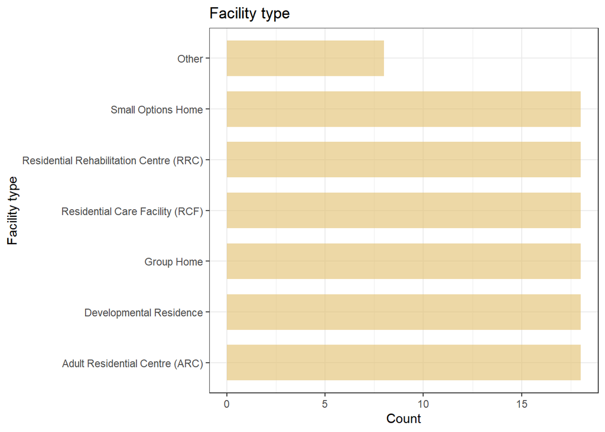

Count of facility type

Figure 1 displays the number of each facility type in the dataset. It reveals that the count for each facility is the same (18), except for those facilities identified as ‘Other’, of which there are only 8 within the dataset.

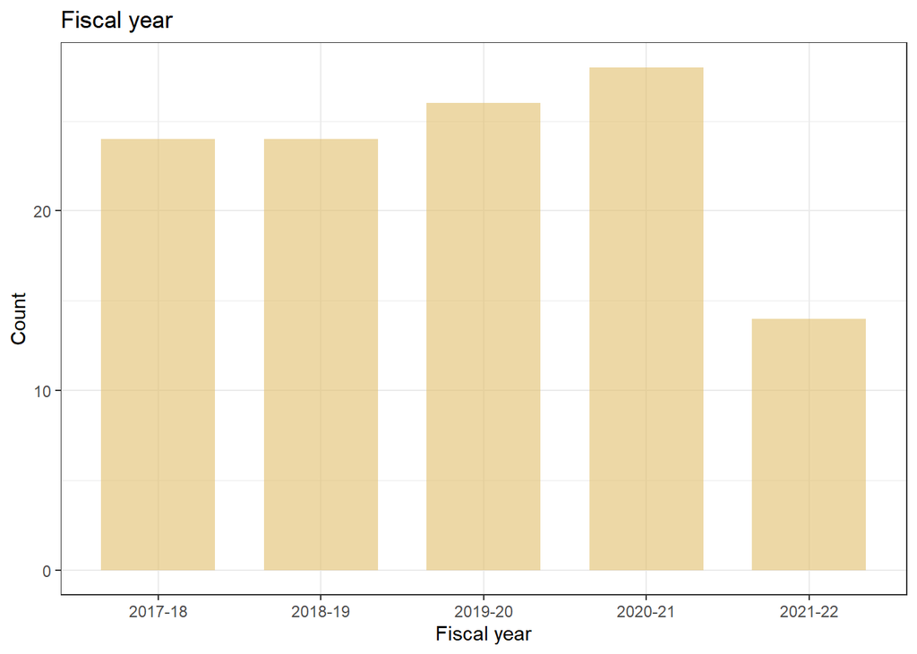

Count of fiscal year

Figure 2 displays the count of the years within the dataset, with the highest count occurring in 2020, followed by 2019. The year with the lowest count is 2021, and may reflect the last update performed on the dataset (November 5, 2021).

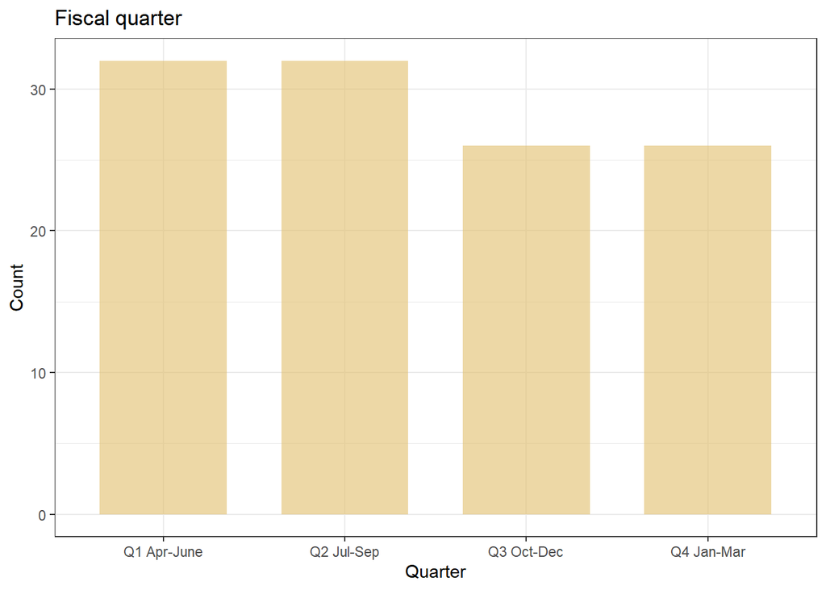

Count of fiscal quarter

Figure 3 displays the count of fiscal quarters contained within the dataset. The highest fiscal quarter count is quarter 1 (April - June) and quarter 2 (July to September), and the lowest is quarter 3 (October to December) and quarter 4 (January to March).

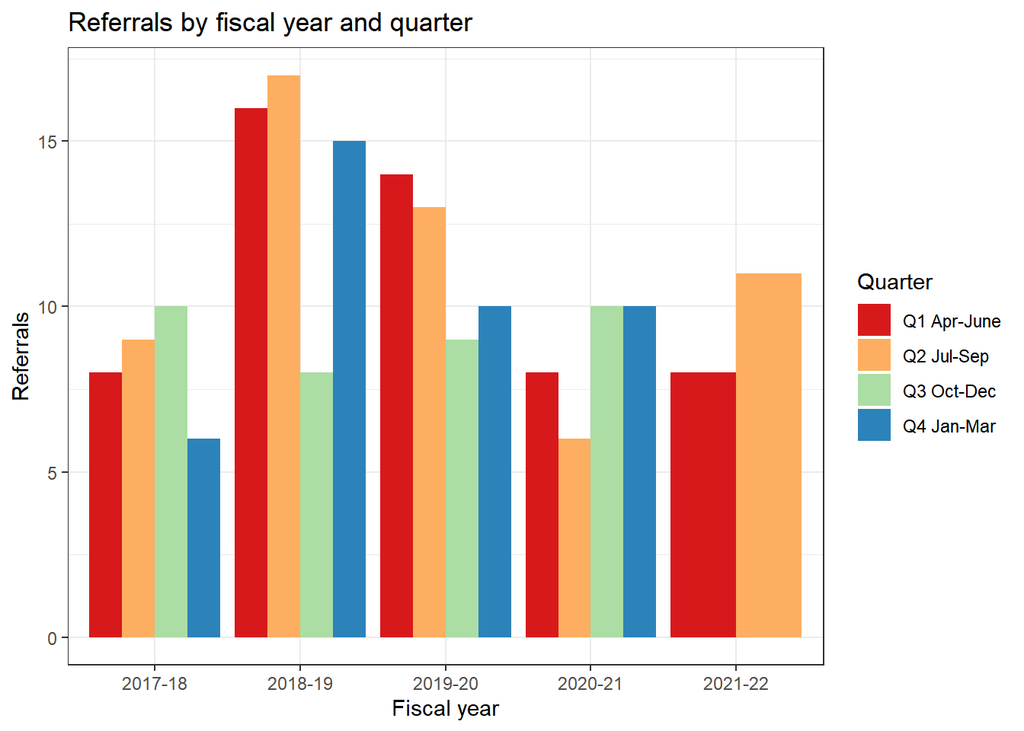

Count of the referrals by fiscal year and quarter

Figure 4 displays the amount of referrals by fiscal year, from 2017 until 2021, as well as the count of fiscal quarters. The highest referrals occurred in 2018, during quarters 1 and 2, while the lowest referral counts occurred in 2017 (quarter 4) and 2020 (quarter 2). There is no data for quarter 3 and quarter 4 in 2021.

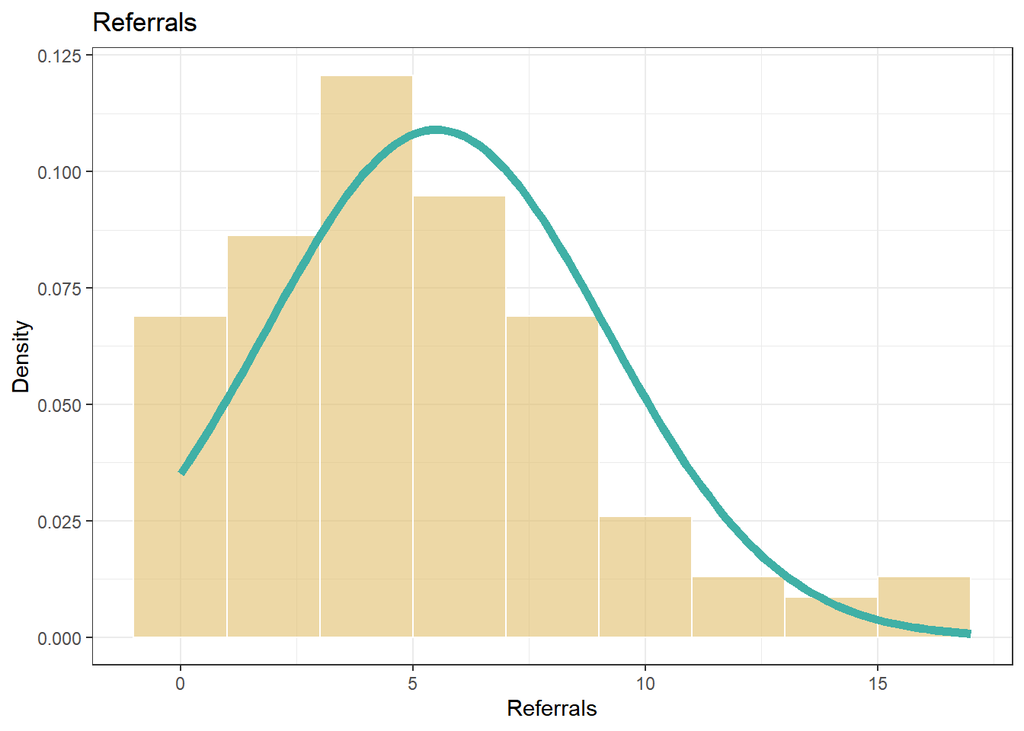

Distribution of referrals

Figure 5 displays the distribution of referrals, with the highest rate of referrals occurring between 4 and 5 referrals, and the lowest occurring between 10 and 15 referrals.

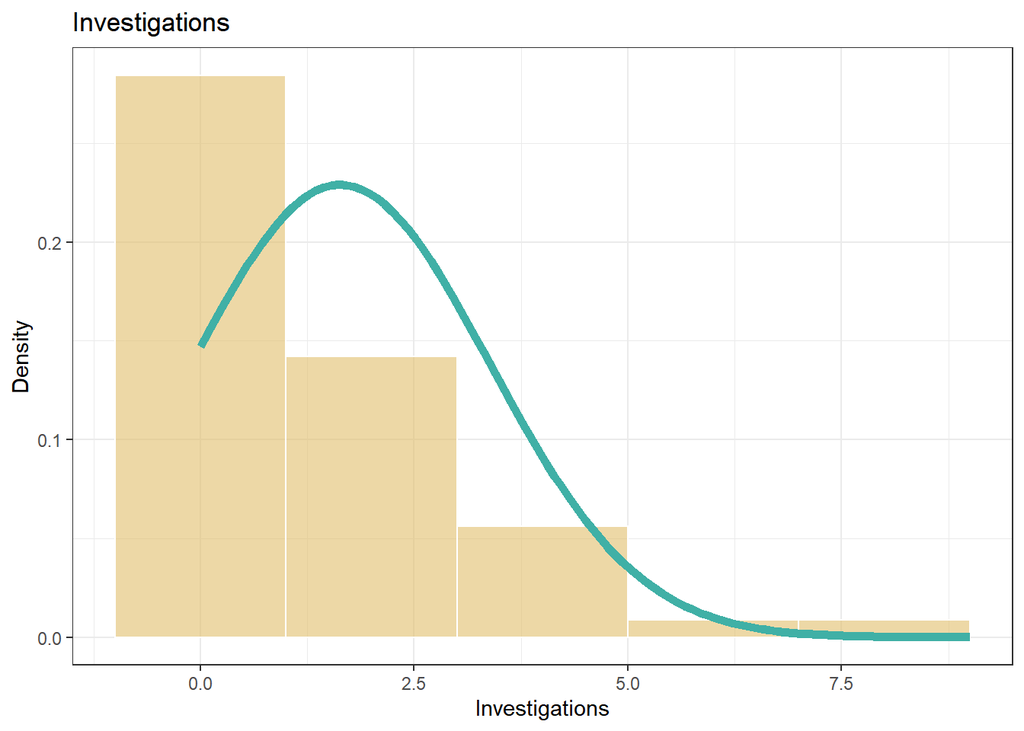

Distribution of investigations

Figure 6 displays the distribution of investigations, with the highest frequency of investigations at 0.0, and the lowest between 5.0 and 7.5 investigations.

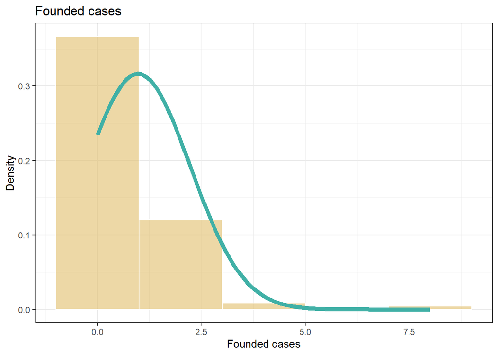

Distribution of founded cases

Figure 7 displays the distribution of founded cases, and has a density curve similar to figure 6. More specifically, the highest distribution occurs at 0.0, with a significant drop after 2.5.

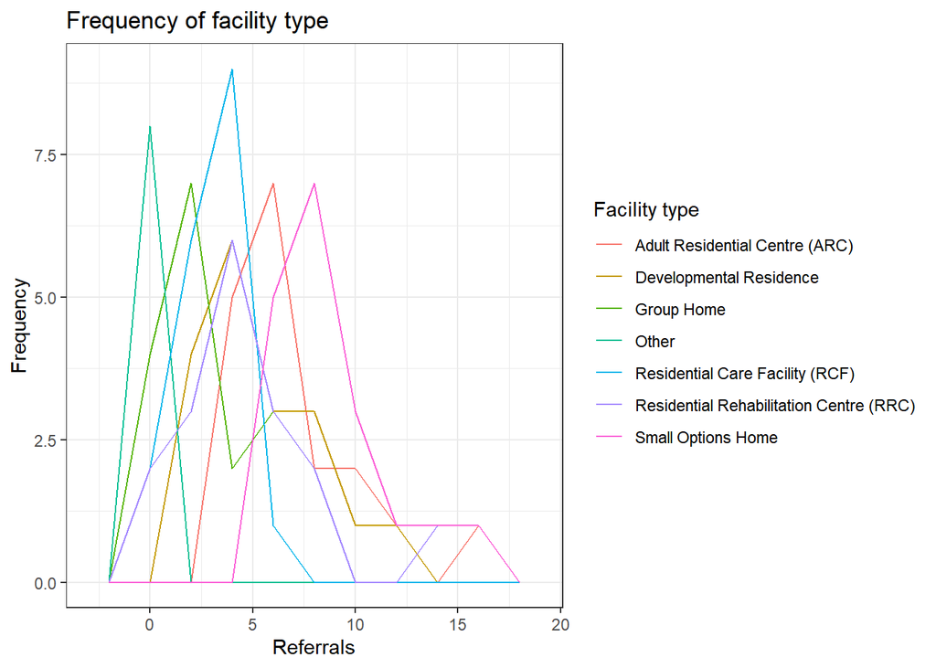

Frequency of facility type in the dataset

Figure 8 displays the frequency of referrals by facility type. From this plot, it can be discerned that the facility types with higher rates of referrals include Small Options Homes and Adult Residential Centres. The facilities types with the lowest rates of referrals include Group Homes and facilities classified as ‘Other’.

# Variation

## A brief description of variation

There is an equal amount (18) of the different facility types in the dataset, with the exception of those facilities classified as ‘Other’, of which there are 8. As well, the facility types with higher rates of referrals include Small Options Homes and Adult Residential Centres. The facilities types with the lowest rates of referrals include Group Homes and facilities classified as ‘Other’.

# Exploration of Covariation

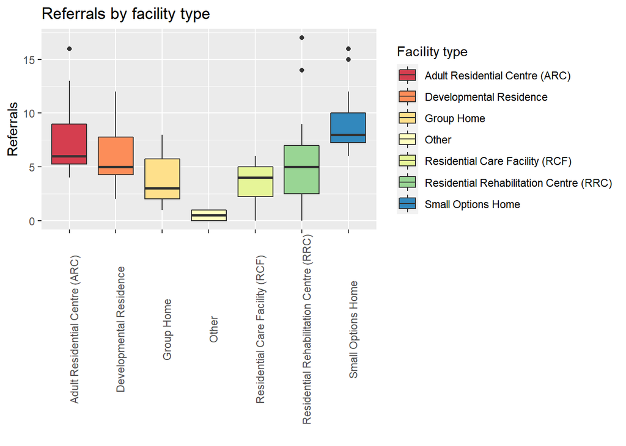

Frequency of referrals by facility type

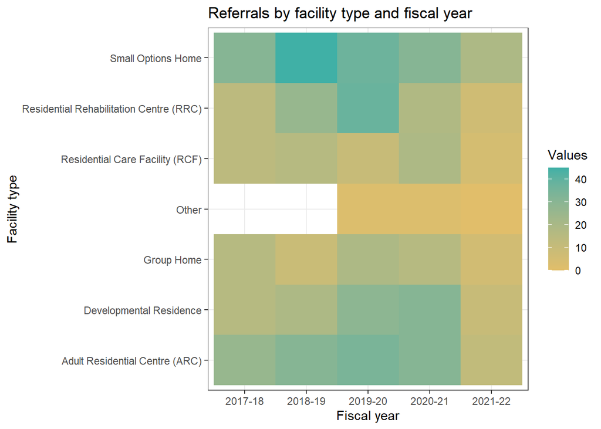

Heatmap of referrals by facility type and fiscal year

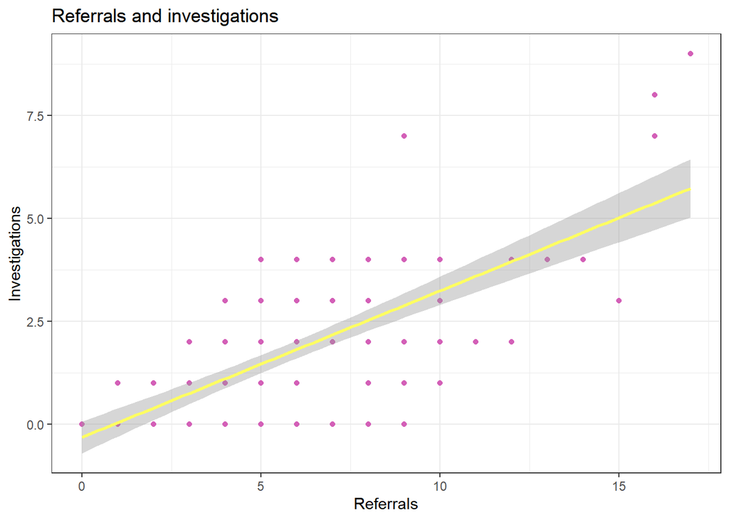

Relationship between referrals and investigations

Figure 11 displays the relationship between referrals and investigations. According to figure 11, there is a slight positive relationship between the number of referrals and the number of investigations that take place.

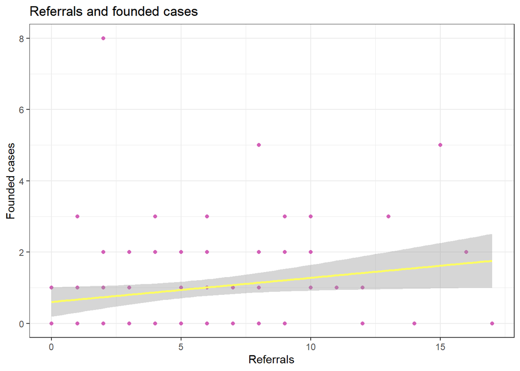

Relationship between referrals and founded cases

Figure 12 displays the relationship between referrals and founded cases. According to figure 12, there little to no correlation between the number of referrals and the number of founded cases.

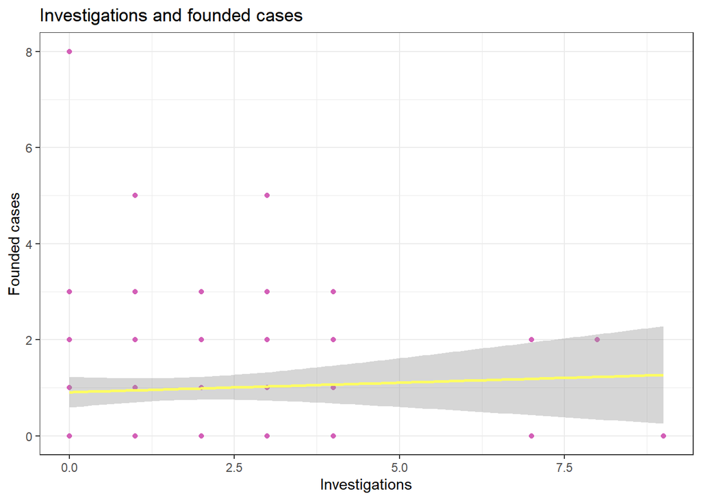

Relationship between investigations and founded cases

Figure 13 displays the relationship between the number of investigations and the number of founded cases. According to figure 13 there is no correlation between the number of investigations and the number of founded cases.

# Covariation

## A brief description of variation

Through covariation analysis, it can be discerned that Small Options Homes and Adult Residential Centres have consistently higher referral rates, while facilities classified as ‘Other’ have low referrals. As well, many referrals occurred in 2019, while 2021 has low referral values and is missing data for quarter 3 (October to December) and quarter 4 (January to March). There is also a slight positive relationship between referrals and investigations, indicating that when a referral occurs, an investigation is likely to take place. However, there is no relationship between referrals and founded cases and no relationship between investigations and founded cases, indicating that referrals and investigations are less likely to result in a founded case.

# Discussion

Before the EDA process, it was assumed that larger facilities would have more referrals due to the staffing and resident numbers. However, the data analysis has revealed that Small Options Homes have the highest rate of referrals, followed by Adult Residential Centres (see Fig. 8, 9, & 10). Additional information about the sizes of the facilities would be beneficial for clarification. As well, further research regarding the operations of Small Options Homes, such as hiring practices, pay scales, educational requirements, etc., could provide meaningful insights into the referral rates for 2017-2021.

It is also important to note that there are 0 referral values for some facility types despite having a founded case; the reason for this is unclear and more information would be beneficial. Similarly, values of 0 for referrals most often occurred with data pertaining to facility types labelled as ‘Other’, a variable which is also missing data for 2017 and 2018. As such, information regarding this category would be advantageous (see Fig. 10).

Through the EDA process, it was revealed that referrals occur more often than investigations and founded cases, and investigations are more likely to occur than founded cases (see Fig. 11, 12, & 13). As well, it appears that an increase in referrals leads to an increase in investigations (see Fig. 11). For the purpose of this report, the EDA process was focused primarily on referrals, as the progression from referral to investigation, and investigation to founded case is unclear. Consequently, information regarding the processes behind referrals, investigations, and founded cases would be beneficial to better understand the data.

Finally, it was hypothesized that 2020 and 2021 would have more referrals due to the COVID-19 pandemic, and the resultant staffing constraints. However, the data for 2021 was incomplete, thus making EDA of 2021 inaccurate. As well, only the count of 2020 within the dataset was higher rather than the rate of referrals (see Fig. 2, 4, & 10). Similarly, no relationship exists between referrals and summer heat or winter holidays, both of which were identified by fiscal quarter, as was assumed before the EDA took place (see Fig. 3 & 4).

In conclusion, visualizing the data was helpful to test theories that had developed through my career as a health care assistant. In the future, it would be beneficial to have more data for 2021 to better analyze the impact of the pandemic. As well, it would be helpful to examine the change in investigations and founded cases across the years in regards to the pandemic - have they increased or decreased? If there are facility visitation restrictions, do those restrictions apply to those that carry out the investigations? How does that impact investigations and founded cases? Consequently, while this report focused heavily on referrals, future modeling exercises should focus on investigations and founded cases across the years, with an emphasis on 2020 and 2021.

# References

Bonnie, R.J. & Wallace, R.B. (Eds). (2003). *Elder Mistreatment: Abuse, Neglect, and Exploitation in an Aging America* Retrieved November 16, 2021 from https://www.ncbi.nlm.nih.gov/books/NBK98802/pdf/Bookshelf_NBK98802.pdf

Government of Nova Scotia. (2021). *Referrals, Investigations and Founded Cases - Licensing Services & Protection for Persons in Care*. Retrieved November 16, 2021 from https://data.novascotia.ca/Community-Services/Referrals-Investigations-and-Founded-Cases-Licensi/3iy7-qqzt